# Tutorial6: Estimación de tiempos de divergencia

Sandra Reinales & Gustavo Ballen

Una vez definidos los *priors* de calibración (tutorial1) y el modelo de reloj que vamos a usar para nuestro análisis de tiempos de divergencia (tutorial5), podemos correr `MCMCtree` usando el gradiente y la matriz hessiana que estimamos anteriormente (tutorial4).

### Preparar el *control file*

Vamos a la terminal, creamos un directorio para el análisis, copiamos allí el *control file* y lo editamos.

```bash
## Asumiendo que estamos en el directorio principal del curso
pwd # Siempre es bueno revisar
mkdir -p divtimest
cp data/mcmctree.ctl divtimest/

## Vamos a editar el *control file*
cd divtimest

# Definir usedata
sed -r -i 's/usedata = 0/usedata = 2 ..\/..\/approximate\/in.BV/g' mcmctree.ctl

# Definir clock. En el tutorial 5 seleccionamos independent clock
sed -r -i 's/clock = 1/clock = 2/g' mcmctree.ctl

## Definir ruta para los archivos de datos
sed -r -i 's/seqfile = ..\/data\/concatenated.phylip/seqfile = ..\/..\/data\/concatenated.phylip/g' mcmctree.ctl

sed -r -i 's/treefile = ..\/data\/startingTree.phy/treefile = ..\/..\/data\/startingTree.phy/g' mcmctree.ctl

## Revisemos
less mcmctree.ctl
```

Es recomendable ejecutar varias corridas independientes de `MCMCtree` con el fin de evaluar la convergencia de las mismas. Para fines de este ejercicio vamos a correr el análisis tres veces. Lo podemos hacer manualmente o usando un *loop*.

```bash
## Asumiendo que continuamos en divtimest
## crear los directorios para las corridas independientes
mkdir -p run1 run2 run3

## Ahora vamos a copiar el *control file* en cada carpeta
cp mcmctree.ctl run1/
cp mcmctree.ctl run2/
cp mcmctree.ctl run3/

## Finalmente vamos a usar un *loop* par correr `MCMCtree`
for d in `seq 1 1 3`; do cd run$d; mcmctree; cd ..; done
```

Después de unos minutos tendremos los resultados del análisis. `MCMCtree` genera un archivo te texto llamado `mcmc.txt` donde están los estimados posteriores de cada uno de los parámetros del modelo incluyendo los estimados de tiempo para cada nodo de la filogenia. Esto es lo que conocemos como *posterior distribution* para cada parámetro.

Podemos usar `Tracer`para revisar detalladamente ese archivo de salida. Este programa permite visualizar el comportamiento del `MCMC`.

Vamos a la terminal:

```bash
## Asumiendo que estamos en divtimest
tracer run1/mcmc.txt # para cargar solo la primera corrida

## Tambien podemos cargar todas las corridas
tracer run1/mcmc.txt run2/mcmc.txt run3/mcmc.txt
```

Podemos examinar también el comportamiento de la media *prior* y la media posterior de la edad de cada nodo, así como el intervalo de 95% HPD.

Vamos a `R` para leer los resultados del análisis de *sample from prior* (tutorial3) y los resultados de `MCMCtree` que acabamos de correr.

```r
## Revisar donde estamos
getwd()
```

```
## [1] "/home/spreinalesl/Dropbox/Sandra/teaching/divTimes_colevol2026/Minicurso_divtimes_colevol2026"
```

```r
## Asumiendo que estamos en el directorio principal del curso
## Leer el archivo del prior
prior <- read.delim("sFRp/mcmc.txt")

## Ahora leámos la posterior
posterior <- read.delim("divtimest/run1/mcmc.txt")
```

Ahora usemos la función `crossplot` de ´tbea` para graficar *prior* vs *posterior*.

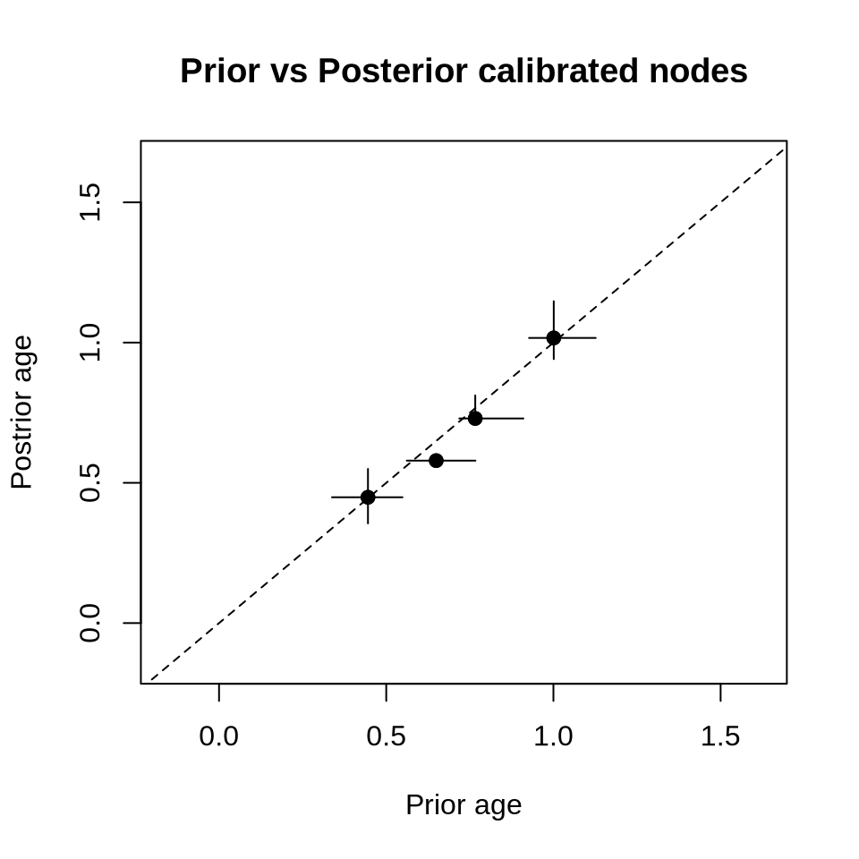

```r
library(tbea)

## Primero vamos a graficar los nodos calibrados
## Para eso tengo que saber en que columna estan
nodes <- c(which(colnames(prior) == "t_n54"), # Root
           which(colnames(prior) == "t_n57"), # Istiophoridae
           which(colnames(prior) == "t_n63"), # Carangidae
           which(colnames(prior) == "t_n77")) # Sphyrenidae

## Ahora si el grafico
crossplot(prior, posterior,
          idx.cols=nodes,
          stat="mean",
          bar.lty=1,
          bar.lwd=1,
          identity.lty=2,
          identity.lwd=1,
          extra.space=0.5,
          main="Prior vs Posterior calibrated nodes",
          xlab="Prior age",
          ylab="Postrior age",
          pch=19)
```

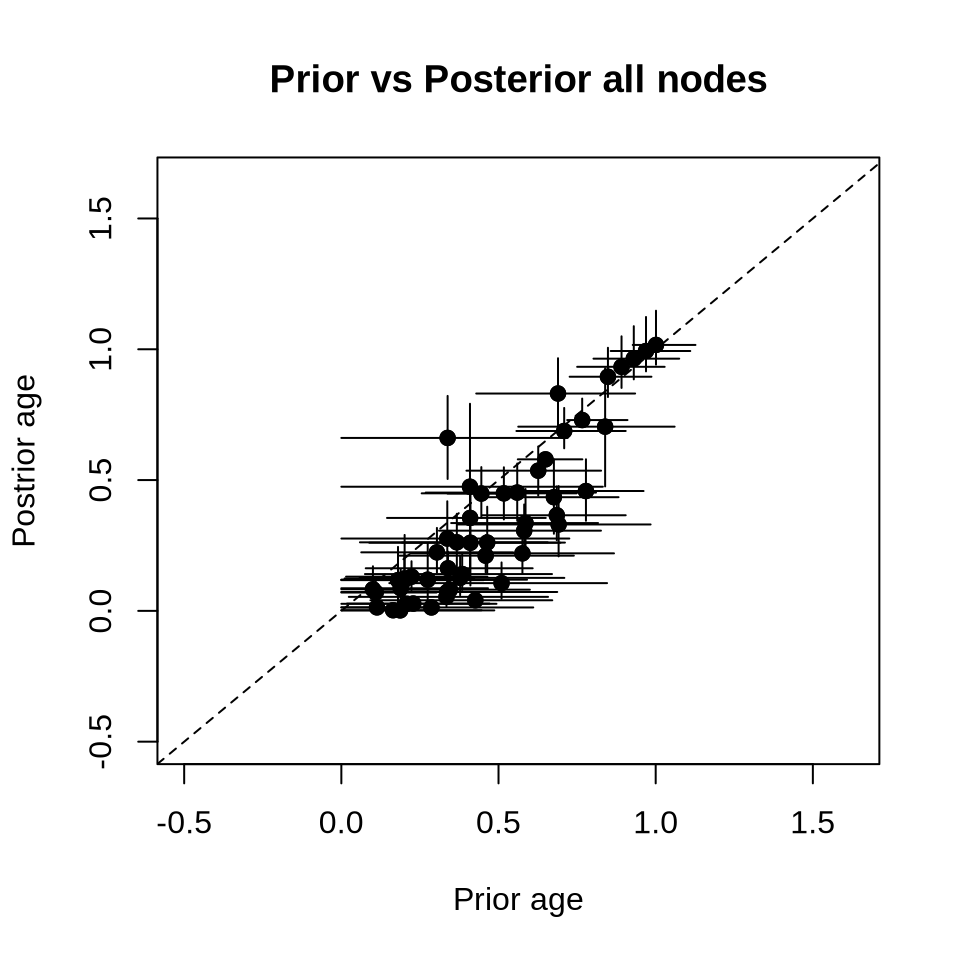

```r
## Que tal todos los nodos
crossplot(prior, posterior,
          pattern="t_n",
          stat="mean",
          bar.lty=1,
          bar.lwd=1,
          identity.lty=2,
          identity.lwd=1,
          extra.space=0.5,
          main="Prior vs Posterior all nodes",
          xlab="Prior age",
          ylab="Postrior age",
          pch=19)
```

También podemos estar interesados en revisar el efecto del *prior* sobre la posterior para un nodo particular. Podemos usar nuevamente `tbea`para esto.

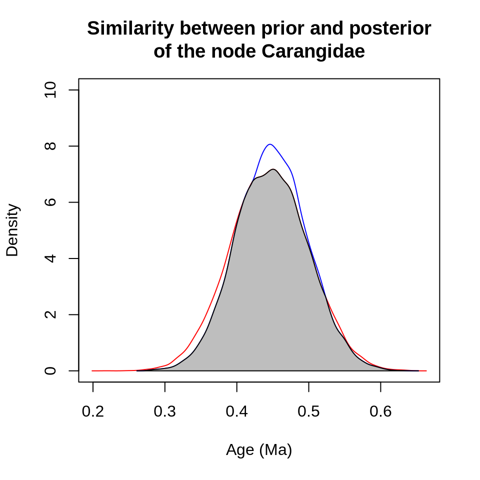

```
## [1] 0.9466465
```

```r
## Integra el area bajo la curva
measureSimil(d1=prior$t_n63,
             d2=posterior$t_n63,
             ylim=c(0, 10),
             xlab="Age (Ma)",
             ylab="Density",
             main="Similarity between prior and posterior\nof the node Carangidae")
```

Finalmente, cómo combinar corridas independientes?